# Introduction to Visualization in Python

## by Shashwat Sridhar

#### 29th June, 2020

## Inspiration

Heavliy inspired by Jake VanderPlas' talk (PyCon 2017)

Links, and further resources at the end of the presentation

# Outline

- Brief history of visualization in python (aka "what is matplotlib?")
- Why (not) matplotlib?
- Overview of available viz libraries in Python
- Which libraries to use when
- Delving deeper:
  - pandas+seaborn
  - holoviews
  - pyqtgraph

# Brief history of data visualization in Python

- began with Matplotlib in 2003
  - meant to replicate plotting functionality of Matlab
- actively developed, robust, huge codebase and active community

[figure not shown]

## Matplotlib is great for...

- creating practically any plot/graphic
- embedding into modules/scripts/libraries to generate system agnostic output

## but not so great for...

- creating practically any plot/graphic quickly/efficiently
- interacting with your visualizations
- working with very large datasets

[figure not shown]

# Plenty of alternatives

[figure not shown]

## Matplotlib-based

MPL, pandas, seaborn, ggpy, etc.

- use MPL as a stable backend to provide high-level plotting functions
- often designed for specific use-case scenarios
- easier to customize if you already know MPL
- very limited/clunky options for interactivity
- very limited 3d support

## Javascript-based

Bokeh, plotly, pythreejs, etc.

- designed to bring python viz to web-browsers (notebooks)
- interactivity is easier to implement, works smoothly
- interactivity doesn't always scale well with data size
- very limited 3d support

## d3js based

altair, vincent, etc.

- declarative approach to plotting (what to plot, rather than how to plot it)
- alternative (more intuitive?) approach to creating graphs
- relatively new, but being actively developed
- customization options limited compared to MPL

## openGL-based

pyqtgraph, vispy, pyglet, glumpy, ext.

- high-performance packages, meant to integrated into standalone apps
- handle large datasets, can harness CPU/GPU power better
- cannot embed into web-browsers, thus, a bit inconvenient for exploration

## Special mention

- pandas
  - organize data in dataframes
  - supported by most new plotting libraries (also by MPL now)
  - forces you to think about how your data should be organized before you go into plotting it
- holoviews
  - provides high-level plotting functionality to work with multiple backends (MPL, bokeh, datashader) in the browser
  - interactivity enabled by default (zoom, pan, select, etc.)
  - number of customizations possible, depending on backend chosen
  - can handle large datasets and streaming data
- pyqtgraph
  - designed to create or integrate with PyQt applications
  - complete interactivity, with customization only limited by knowledge of Python
  - can handle large datasets and streaming data
- altair
  - declarative grammar is very appealing
  - discussed in depth by Jake VanderPlas (refer to resources)

# What to use when?

- Quick exploratory data analysis: matplotlib, pandas+seaborn, pygal
- sharing results / collaborating:
  - static images: same as above
  - interactive: jupyter lab + (holoviews / altair)
- high performance visualizations:
  - in-browser: holoviews
  - standalone: pyqtgraph
- graphics for publicatins:
  - seaborn + pandas (+ matplotlib)

# Specific examples

# Quick setup

```python
import numpy as np
import pandas as pd
import seaborn as sns; sns.set(style="ticks", color_codes=True)
import matplotlib.pyplot as plt
import holoviews as hv
from holoviews import opts
hv.extension("bokeh")
from sklearn.datasets import load_wine
from IPython.display import Video
```

## Fetch/load data

```python
# load dataset
wine_dataset = load_wine()
```

```python
# examine parts of dataset
wine_dataset.keys()
```

```
dict_keys(['data', 'target', 'frame', 'target_names', 'DESCR', 'feature_names'])
```

```python
data = wine_dataset['data']
target = wine_dataset['target']
frame = wine_dataset['frame']
target_names = wine_dataset['target_names']
description = wine_dataset['DESCR']
feature_names = wine_dataset['feature_names']
```

```python
# features available
print(feature_names)
```

```
['alcohol', 'malic_acid', 'ash', 'alcalinity_of_ash', 'magnesium', 'total_phenols', 'flavanoids', 'nonflavanoid_phenols', 'proanthocyanins', 'color_intensity', 'hue', 'od280/od315_of_diluted_wines', 'proline']
```

## Create Pandas dataframe

```python
df = pd.DataFrame(data, columns=feature_names)
```

```python
# select columns
attributes = feature_names[:5]
```

```python
df
```

|  | alcohol | malic_acid | ash | alcalinity_of_ash | magnesium | total_phenols | flavanoids | nonflavanoid_phenols | proanthocyanins | color_intensity | hue | od280/od315_of_diluted_wines | proline |
| --- | --- | --- | --- | --- | --- | --- | --- | --- | --- | --- | --- | --- | --- |
| 0 | 14.23 | 1.71 | 2.43 | 15.6 | 127.0 | 2.80 | 3.06 | 0.28 | 2.29 | 5.64 | 1.04 | 3.92 | 1065.0 |
| 1 | 13.20 | 1.78 | 2.14 | 11.2 | 100.0 | 2.65 | 2.76 | 0.26 | 1.28 | 4.38 | 1.05 | 3.40 | 1050.0 |
| 2 | 13.16 | 2.36 | 2.67 | 18.6 | 101.0 | 2.80 | 3.24 | 0.30 | 2.81 | 5.68 | 1.03 | 3.17 | 1185.0 |
| 3 | 14.37 | 1.95 | 2.50 | 16.8 | 113.0 | 3.85 | 3.49 | 0.24 | 2.18 | 7.80 | 0.86 | 3.45 | 1480.0 |
| 4 | 13.24 | 2.59 | 2.87 | 21.0 | 118.0 | 2.80 | 2.69 | 0.39 | 1.82 | 4.32 | 1.04 | 2.93 | 735.0 |
| ... | ... | ... | ... | ... | ... | ... | ... | ... | ... | ... | ... | ... | ... |
| 173 | 13.71 | 5.65 | 2.45 | 20.5 | 95.0 | 1.68 | 0.61 | 0.52 | 1.06 | 7.70 | 0.64 | 1.74 | 740.0 |
| 174 | 13.40 | 3.91 | 2.48 | 23.0 | 102.0 | 1.80 | 0.75 | 0.43 | 1.41 | 7.30 | 0.70 | 1.56 | 750.0 |
| 175 | 13.27 | 4.28 | 2.26 | 20.0 | 120.0 | 1.59 | 0.69 | 0.43 | 1.35 | 10.20 | 0.59 | 1.56 | 835.0 |
| 176 | 13.17 | 2.59 | 2.37 | 20.0 | 120.0 | 1.65 | 0.68 | 0.53 | 1.46 | 9.30 | 0.60 | 1.62 | 840.0 |
| 177 | 14.13 | 4.10 | 2.74 | 24.5 | 96.0 | 2.05 | 0.76 | 0.56 | 1.35 | 9.20 | 0.61 | 1.60 | 560.0 |

178 rows × 13 columns

```python
attributes
```

```
['alcohol', 'malic_acid', 'ash', 'alcalinity_of_ash', 'magnesium']
```

# Matplotlib

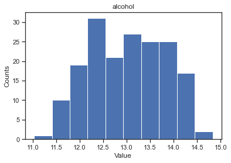

```python
fig, axis = plt.subplots()
axis.hist(df[feature_names[0]])
axis.set_title(feature_names[0])
axis.set_xlabel("Value")
axis.set_ylabel("Counts")
plt.show()
```

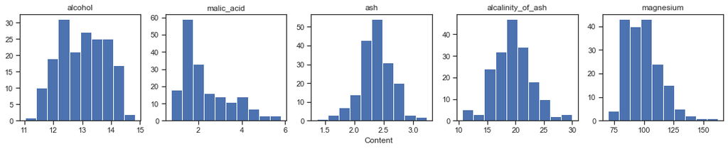

```python
fig, axes = plt.subplots(nrows=1, ncols=len(attributes), figsize=(3*len(attributes), 3))
for i, axis in enumerate(axes):
    axis.hist(df[attributes[i]])
    axis.set_title(attributes[i])

fig.text(x=0.5, y=0.0, s="Content")
plt.tight_layout()
plt.show()
```

# Pandas only

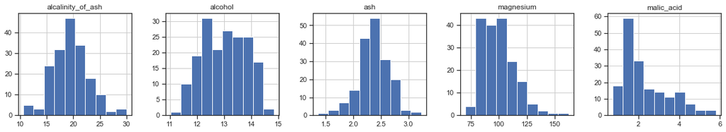

```python
# histograms
df[attributes].hist(figsize=(20, 3), layout=(1,5))
plt.show()
```

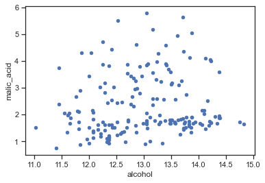

```python
# scatter plot
df[attributes].plot.scatter(x='alcohol', y='malic_acid', c='b')
plt.show()
```

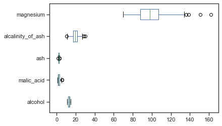

```python
# line plot
df[attributes].plot.box(vert=False)
plt.show()
```

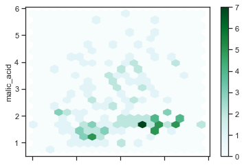

```python
# hexbin plot
df[attributes].plot.hexbin(x='alcohol', y='malic_acid', gridsize=20)
plt.show()
```

# Pandas+Seaborn

### Restructure dataframe

```python
df['sample'] = np.array(['sample_' + str(i) for i in range(len(df.index))])
restructured_df = df.melt(id_vars='sample', value_vars=feature_names, var_name="features", value_name="values")
```

```python
df
```

|  | alcohol | malic_acid | ash | alcalinity_of_ash | magnesium | total_phenols | flavanoids | nonflavanoid_phenols | proanthocyanins | color_intensity | hue | od280/od315_of_diluted_wines | proline | sample |
| --- | --- | --- | --- | --- | --- | --- | --- | --- | --- | --- | --- | --- | --- | --- |
| 0 | 14.23 | 1.71 | 2.43 | 15.6 | 127.0 | 2.80 | 3.06 | 0.28 | 2.29 | 5.64 | 1.04 | 3.92 | 1065.0 | sample_0 |
| 1 | 13.20 | 1.78 | 2.14 | 11.2 | 100.0 | 2.65 | 2.76 | 0.26 | 1.28 | 4.38 | 1.05 | 3.40 | 1050.0 | sample_1 |
| 2 | 13.16 | 2.36 | 2.67 | 18.6 | 101.0 | 2.80 | 3.24 | 0.30 | 2.81 | 5.68 | 1.03 | 3.17 | 1185.0 | sample_2 |
| 3 | 14.37 | 1.95 | 2.50 | 16.8 | 113.0 | 3.85 | 3.49 | 0.24 | 2.18 | 7.80 | 0.86 | 3.45 | 1480.0 | sample_3 |
| 4 | 13.24 | 2.59 | 2.87 | 21.0 | 118.0 | 2.80 | 2.69 | 0.39 | 1.82 | 4.32 | 1.04 | 2.93 | 735.0 | sample_4 |
| ... | ... | ... | ... | ... | ... | ... | ... | ... | ... | ... | ... | ... | ... | ... |
| 173 | 13.71 | 5.65 | 2.45 | 20.5 | 95.0 | 1.68 | 0.61 | 0.52 | 1.06 | 7.70 | 0.64 | 1.74 | 740.0 | sample_173 |
| 174 | 13.40 | 3.91 | 2.48 | 23.0 | 102.0 | 1.80 | 0.75 | 0.43 | 1.41 | 7.30 | 0.70 | 1.56 | 750.0 | sample_174 |
| 175 | 13.27 | 4.28 | 2.26 | 20.0 | 120.0 | 1.59 | 0.69 | 0.43 | 1.35 | 10.20 | 0.59 | 1.56 | 835.0 | sample_175 |
| 176 | 13.17 | 2.59 | 2.37 | 20.0 | 120.0 | 1.65 | 0.68 | 0.53 | 1.46 | 9.30 | 0.60 | 1.62 | 840.0 | sample_176 |
| 177 | 14.13 | 4.10 | 2.74 | 24.5 | 96.0 | 2.05 | 0.76 | 0.56 | 1.35 | 9.20 | 0.61 | 1.60 | 560.0 | sample_177 |

178 rows × 14 columns

```python
restructured_df
```

|  | sample | features | values |
| --- | --- | --- | --- |
| 0 | sample_0 | alcohol | 14.23 |
| 1 | sample_1 | alcohol | 13.20 |
| 2 | sample_2 | alcohol | 13.16 |
| 3 | sample_3 | alcohol | 14.37 |
| 4 | sample_4 | alcohol | 13.24 |
| ... | ... | ... | ... |
| 2309 | sample_173 | proline | 740.00 |
| 2310 | sample_174 | proline | 750.00 |
| 2311 | sample_175 | proline | 835.00 |
| 2312 | sample_176 | proline | 840.00 |
| 2313 | sample_177 | proline | 560.00 |

2314 rows × 3 columns

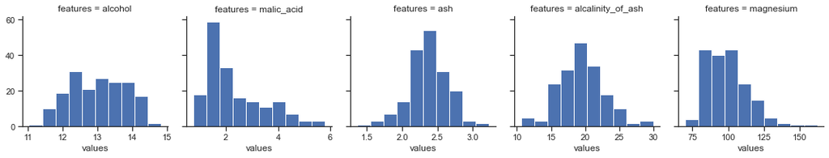

```python
grid = sns.FacetGrid(restructured_df[np.isin(restructured_df['features'], attributes)], col='features', col_wrap=6, sharex=False)
grid = grid.map(plt.hist, 'values')
```

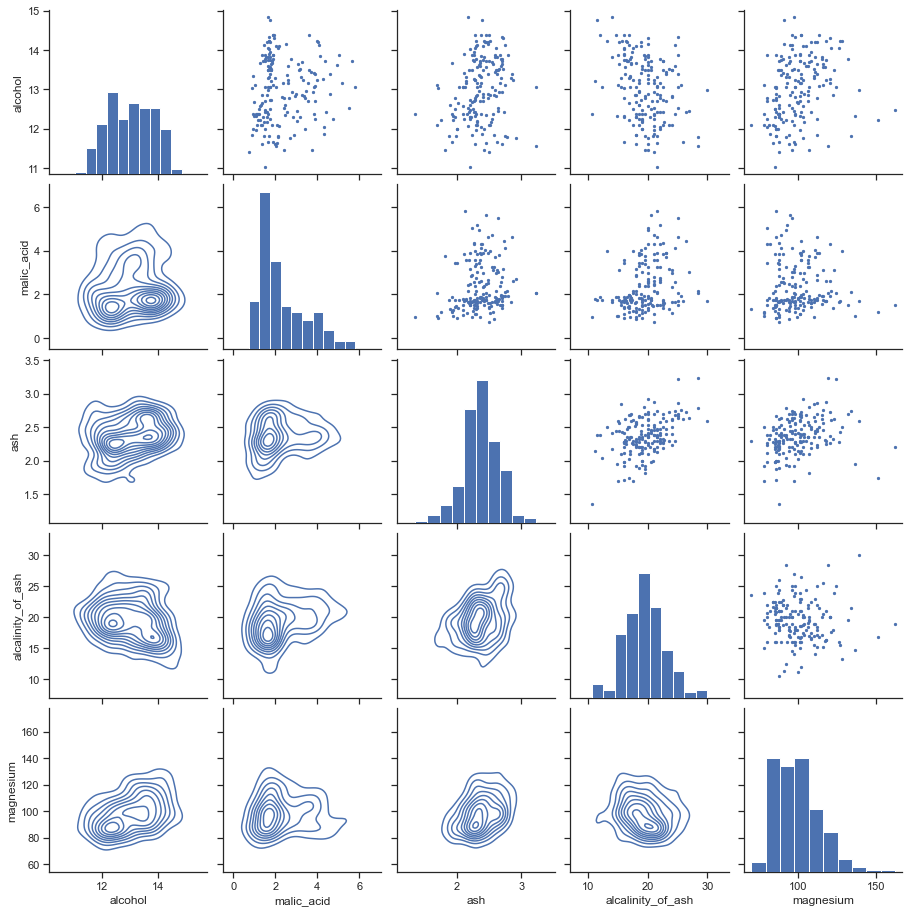

```python
g = sns.PairGrid(df[attributes])
g = g.map_diag(plt.hist)
g = g.map_upper(plt.scatter, s=5)
g = g.map_lower(sns.kdeplot, colors="C0")
```

```python
result_df = df.copy()
result_df['target'] = pd.Series(target)
```

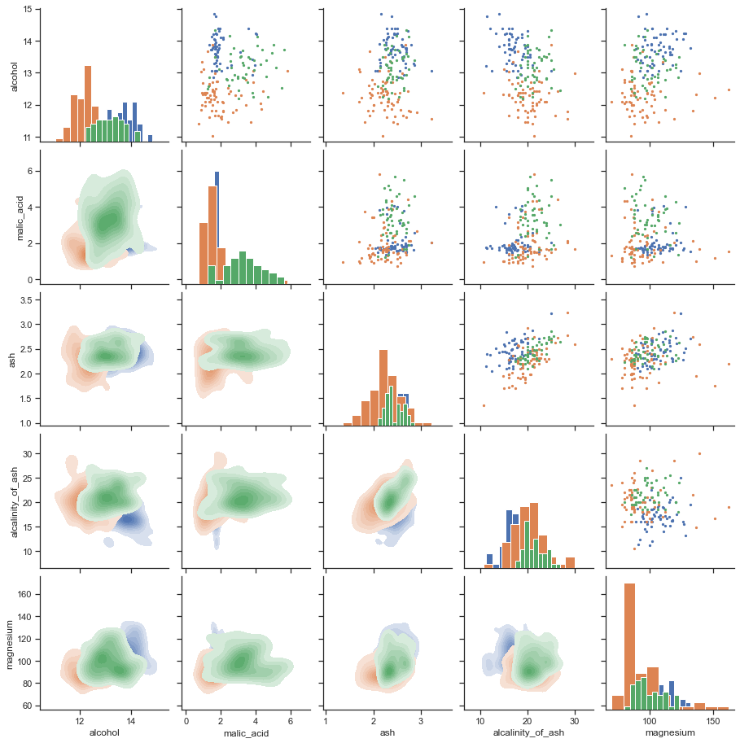

```python
g = sns.PairGrid(result_df[attributes + ['target']], hue='target')
g = g.map_diag(plt.hist)
g = g.map_upper(plt.scatter, s=5)
g = g.map_lower(sns.kdeplot, cumulative=False, shade=True, shade_lowest=False)
```

[figure not shown]

# Holoviews

```python
y, x = np.histogram(df[attributes[0]])
hv.Histogram((x, y))
```

[interactive chart not shown]

### Create elements

```python
curve = hv.Curve((x, y)).opts(color='red')
hist = hv.Histogram(curve)
```

### Overlay elements

```python
hist*curve
```

[interactive chart not shown]

### Combine elements

```python
hist+curve
```

[interactive chart not shown]

```python
%%opts Layout [shared_axes=False]

hv_plots = []
for attribute in attributes:
    y, x = np.histogram(df[attribute])
    hist = hv.Histogram((x, y), label=attribute)
    hv_plots.append(hist)

hv.Layout(hv_plots).cols(len(attributes))
```

[interactive chart not shown]

```python
scatter_points = hv.Points(df[attributes[:2]].to_numpy())
scatter_points.hist(dimension=['x', 'y']).redim.label(x=attributes[0], y=attributes[1])
```

[interactive chart not shown]

```python
from holoviews.operation import gridmatrix

ds = hv.Dataset(df[attributes])
```

```python
gridmatrix(ds)
```

[interactive chart not shown]

## Developing library, many more possibilities

[figure not shown]

# PyQtGraph

### (or pyqtgraph)

```
import sys
import numpy as np
import pandas as pd
import pyqtgraph as pg
from pyqtgraph.Qt import QtGui, QtCore, QtWidgets
from sklearn.datasets import load_wine


if __name__ == "__main__":
    app = QtGui.QApplication(sys.argv)
    pg_win = pg.GraphicsLayoutWidget()

    dataset = load_wine()
    data = dataset['data']
    features = dataset["feature_names"]

    attributes = features[:5]

    df = pd.DataFrame(data, columns=features)

    plots = []

    for a, attribute in enumerate(attributes):
        y, x = np.histogram(df[attribute])
        plot = pg_win.addPlot(name=attribute, title=attribute)
        plot.plot(x, y, stepMode=True, fillLevel=0, fillOutline=True, brush=(0, 0, 255, 128))
        plot.setLabel("bottom", "Values")
        if a == 0:
            plot.setLabel("left", "Counts")
        plots.append(plot)

    for plot in plots[1:]:
        plot.setYLink(plots[0])

    pg_win.show()
    sys.exit(app.exec_())
```

[figure not shown]

## Fast and lightweight

```
from pyqtgraph import examples
examples.run()
```

[figure not shown]

## Embedding into complete applications

```python
Video("./graphics/swan_1.mp4")
```

[video not shown]

# External links and resources

- Jake VanderPlas' talk + slides: https://www.youtube.com/watch?v=FytuB8nFHPQ https://speakerdeck.com/jakevdp/pythons-visualization-landscape-pycon-2017
- Pyviz website: www.pyviz.org
- Python Data Visualization 2018: Why So Many Libraries? https://www.anaconda.com/blog/python-data-visualization-2018-why-so-many-libraries
- A Dramatic Tour through Python’s Data Visualization Landscape (including ggplot and Altair) (**this is hilarious**) https://dsaber.com/2016/10/02/a-dramatic-tour-through-pythons-data-visualization-landscape-including-ggplot-and-altair/
- A reddit thread https://www.reddit.com/r/Python/comments/4hdqb6/difference_between_plotting_libraries/
- Recent Medium blogpost https://medium.com/@lulunana/python-visualization-landscape-3b95ede3d030